# Unit_9_Assignment

Matt Chinchilla

7/6/2019

```r
#Libraries
library(dplyr)
library(ggplot2)
library(knitr)
library(kableExtra)
library(sjPlot)
library(sjlabelled)
library(sjmisc)
```

#### A. Clean an prepare the Data:

##### Download Data

```r
#Create Data frame for Beers.csv data
Beers <- read.csv("./Beers.csv")

#Create data frame for Breweries.cvs
Breweries <- read.csv("./Breweries.csv")
```

##### 2. Merge Data into data frame

```r
#Merge into new dataframe BeersBreweries
BeersBreweries <- inner_join(Beers,Breweries, by = c("Brewery_id" = "Brew_ID"))

#Rename columns from Name.x and Name.y to Beer_Name and Brewery_Name
names(BeersBreweries)[1] <- c("Beer_Name")
names(BeersBreweries)[8] <- c("Brewery_Name")
```

##### 3. Clean white spaces in State abbreviations.

```r
#trim the white space in state abbreviations
BeersBreweries$State <- trimws(BeersBreweries$State)
```

##### 4. Create Data frame beerCOTX with only Colorado and Texas beers. Exclude NA’s from new data frame

```r
#Create subset of BeersBreweries with only Texas and Colorado Breweries
beerCOTX <- filter(BeersBreweries, State == c("TX","CO"))

#Omit all rows from beerCOTX with null value for IBU
beerCOTX <- beerCOTX %>% na.omit(beerCOTX$IBU)
```

##### 5. Order beerCOTX by IBU asscending. View data.

```r
#Arrange Rows in ascending order by IBU
beerCOTX <- beerCOTX %>% arrange(IBU)

#View beerCOTX
kable(head(beerCOTX)) %>% kable_styling(bootstrap_options = "striped")
```

| Beer_Name | Beer_ID | ABV | IBU | Brewery_id | Style | Ounces | Brewery_Name | City | State |
| --- | --- | --- | --- | --- | --- | --- | --- | --- | --- |
| 18th Anniversary Gose | 2370 | 0.044 | 5 | 129 | Gose | 12 | Real Ale Brewing Company | Blanco | TX |
| Dry Dock Hefeweizen | 872 | 0.043 | 12 | 497 | Hefeweizen | 12 | Dry Dock Brewing Company | Aurora | CO |
| Broken Bridge | 2117 | 0.056 | 12 | 216 | Dunkelweizen | 12 | Texian Brewing Co. | Richmond | TX |
| Morning Wood Wheat (Current) | 2360 | 0.059 | 14 | 136 | American Pale Wheat Ale | 12 | Pug Ryan’s Brewery | Dillon | CO |
| Morning Wood Wheat (Current) | 130 | 0.059 | 14 | 136 | American Pale Wheat Ale | 12 | Pug Ryan’s Brewery | Dillon | CO |
| SummerBright Ale | 397 | 0.045 | 15 | 392 | American Pale Wheat Ale | 12 | Breckenridge Brewery | Denver | CO |

#### B.

##### 6. Create Initial plots of Texas and Colorado Data

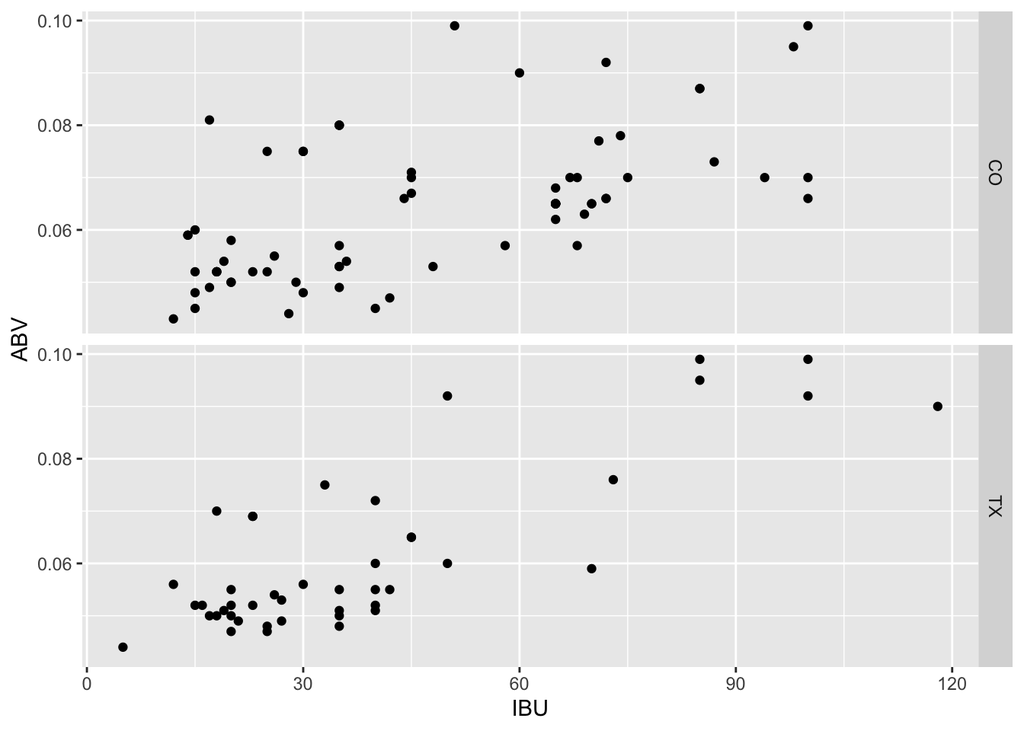

```r
#Plot IBU and ABV for all values in beerCOTX and assign to variable p
p <- ggplot(beerCOTX, aes(IBU, ABV)) + geom_point()

#Split the previous plot into two based on state
p + facet_grid(State ~.)
```

#### C. Model the data

##### 7a. Texas model

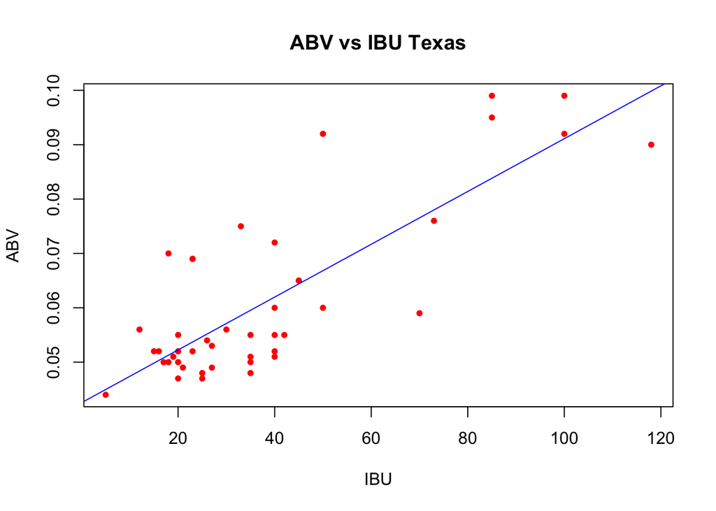

```r
#Split beerCOTX by state

#Texas Breweries
beerTX <- filter(beerCOTX, State == "TX")

#Calculate coeficients
lmtx <- lm(ABV ~ IBU, data = beerTX)

#Grab coefficients data
coefs <- coef(lmtx)

#Plot using base plot function.
plot(beerTX$IBU, beerTX$ABV, pch=20, col = "red", xlab = "IBU", ylab = "ABV", main = "ABV vs IBU Texas")
abline(coefs[1], coefs[2], col = "blue")
```

##### 7b. Colorado Model

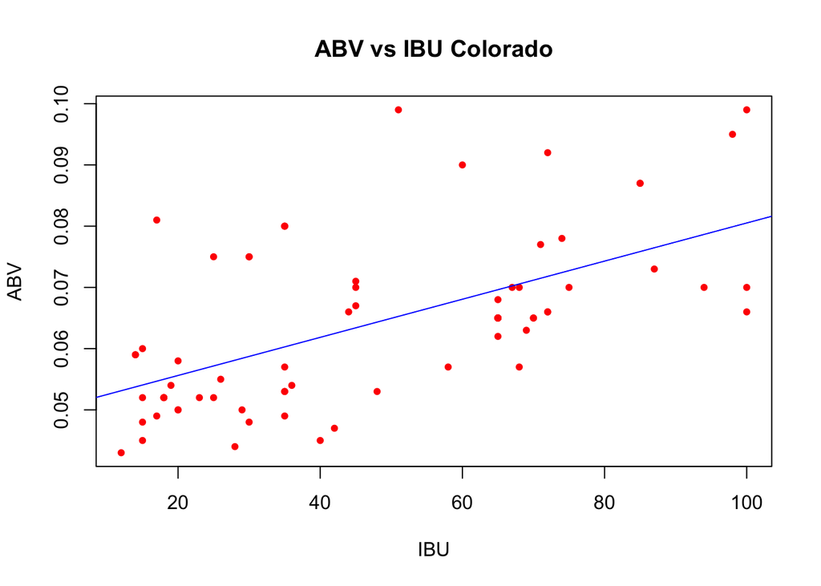

```r
#Split beerCOTX by state

#Colorado Breweries
beerCO <- filter(beerCOTX, State == "CO")

#Calculate coeficients
lmco <- lm(ABV ~ IBU, data = beerCO)

#Grab coefficients data
coefs1 <- coef(lmco)

#Plot using base plot function.
plot(beerCO$IBU, beerCO$ABV, pch=20, col = "red", xlab = "IBU", ylab = "ABV", main = "ABV vs IBU Colorado")
abline(coefs1[1], coefs1[2], col = "blue")
```

##### 8. Address the assumptions of the regression model.

##### 8a.

```r
#Texas
length(beerTX$Beer_ID)
```

```
## [1] 44
```

```r
#Colorado
length(beerCO$Beer_ID)
```

```
## [1] 72
```

##### 8b. The normal distributions for Texas and Colorado do not have equal standard deviations.

```r
# Standard deviation Texas
sd(beerTX$ABV)
```

```
## [1] 0.01555028
```

```r
# Standard deviation Colorado
sd(beerCO$ABV)
```

```
## [1] 0.01366913
```

##### 8c.The mean of the distributions have a linear relationship to IBU??? Also not sure how to do this

##### 8d. Independance ??? Not sure how to do this

#### D. Gain inference from the model

##### 9a. The Texas model has an R^2 variance of 65% adjusted to 64%. This shows me the model can explane over 50% of the variance in ABV.

```r
#Parameter estimate table Texas
tab_model(lmtx)
```

|  | ABV |  |  |
| --- | --- | --- | --- |
| Predictors | Estimates | CI | p |
| (Intercept) | 0.04 | 0.04 – 0.05 | **<0.001** |
| IBU | 0.00 | 0.00 – 0.00 | **<0.001** |
| Observations | 44 |  |  |
| R<sup>2</sup> / adjusted R<sup>2</sup> | 0.651 / 0.642 |  |  |

##### 9b. The Colorado model has an R^2 variance of 34.5% adjusted to 33.6%. This shows me the model can explane less than 50% of the variance in ABV. This is probably not a good model for Colorado.

```r
#Parameter estimate table Colorado
tab_model(lmco)
```

|  | ABV |  |  |
| --- | --- | --- | --- |
| Predictors | Estimates | CI | p |
| (Intercept) | 0.05 | 0.04 – 0.05 | **<0.001** |
| IBU | 0.00 | 0.00 – 0.00 | **<0.001** |
| Observations | 72 |  |  |
| R<sup>2</sup> / adjusted R<sup>2</sup> | 0.345 / 0.336 |  |  |

##### 9c. Based on my observations there does seem to be evidence that the relationship between ABV and IBU are diffent in Texas and Colorado.

##### 10 I have no idea???

#### E. Compare two competing models

##### 11. Create a new column IBU2 with the square of IBU for each row.

```r
#Add column IBU2 to beerCOTX data frame.
beerCOTX$IBU2 <- beerCOTX$IBU ^ 2

#Confirm new column
kable(head(beerCOTX)) %>% kable_styling(bootstrap_options = "striped")
```

| Beer_Name | Beer_ID | ABV | IBU | Brewery_id | Style | Ounces | Brewery_Name | City | State | IBU2 |
| --- | --- | --- | --- | --- | --- | --- | --- | --- | --- | --- |
| 18th Anniversary Gose | 2370 | 0.044 | 5 | 129 | Gose | 12 | Real Ale Brewing Company | Blanco | TX | 25 |
| Dry Dock Hefeweizen | 872 | 0.043 | 12 | 497 | Hefeweizen | 12 | Dry Dock Brewing Company | Aurora | CO | 144 |
| Broken Bridge | 2117 | 0.056 | 12 | 216 | Dunkelweizen | 12 | Texian Brewing Co. | Richmond | TX | 144 |
| Morning Wood Wheat (Current) | 2360 | 0.059 | 14 | 136 | American Pale Wheat Ale | 12 | Pug Ryan’s Brewery | Dillon | CO | 196 |
| Morning Wood Wheat (Current) | 130 | 0.059 | 14 | 136 | American Pale Wheat Ale | 12 | Pug Ryan’s Brewery | Dillon | CO | 196 |
| SummerBright Ale | 397 | 0.045 | 15 | 392 | American Pale Wheat Ale | 12 | Breckenridge Brewery | Denver | CO | 225 |

##### 12a. Split the beerCOTX data into training and test data frames based on state

##### Texas training and test data frames

```r
# Filter on Texas data
beerTX <- filter(beerCOTX, State == "TX")

# Create random sample set of Texas training observations based on 60% data for training
TrainObs = sample(seq(1,dim(beerTX)[1]),round(.60*dim(beerTX)[1]), replace = FALSE)

# Create data frame of training observations
TrainingTX <- beerTX[TrainObs,]

# Summary of TrainingTX
summary(TrainingTX)
```

```
##                  Beer_Name     Beer_ID          ABV
##  1836                 : 1   Min.   : 502   Min.   :0.04400
##  18th Anniversary Gose: 1   1st Qu.:1300   1st Qu.:0.05000
##  Alteration           : 1   Median :2093   Median :0.05450
##  BLAKKR               : 1   Mean   :1792   Mean   :0.06073
##  Broken Bridge        : 1   3rd Qu.:2230   3rd Qu.:0.06000
##  Cow Creek            : 1   Max.   :2588   Max.   :0.09900
##  (Other)              :20
##       IBU           Brewery_id                               Style
##  Min.   :  5.00   Min.   : 30.0   American Blonde Ale           : 4
##  1st Qu.: 20.25   1st Qu.:126.0   American Double / Imperial IPA: 3
##  Median : 34.00   Median :129.0   American Pale Ale (APA)       : 3
##  Mean   : 39.65   Mean   :163.5   Saison / Farmhouse Ale        : 2
##  3rd Qu.: 41.50   3rd Qu.:212.5   Altbier                       : 1
##  Max.   :100.00   Max.   :396.0   American Amber / Red Ale      : 1
##                                   (Other)                       :12
##      Ounces                             Brewery_Name       City
##  Min.   :12.00   Karbach Brewing Company      : 4    Houston :5
##  1st Qu.:12.00   Real Ale Brewing Company     : 3    Austin  :4
##  Median :12.00   Deep Ellum Brewing Company   : 2    Blanco  :3
##  Mean   :12.46   Southern Star Brewing Company: 2    Dallas  :3
##  3rd Qu.:12.00   Texian Brewing Co.           : 2    Conroe  :2
##  Max.   :16.00   Branchline Brewing Company   : 1    Richmond:2
##                  (Other)                      :12    (Other) :7
##     State                IBU2
##  Length:26          Min.   :   25.0
##  Class :character   1st Qu.:  410.2
##  Mode  :character   Median : 1157.0
##                     Mean   : 2268.9
##                     3rd Qu.: 1723.0
##                     Max.   :10000.0
##
```

```r
# Create a data frame of test observations
TestTX <- beerTX[-TrainObs,]

# Summary of TrainingTX
summary(TestTX)
```

```
##                  Beer_Name     Beer_ID          ABV
##  Pine Belt Pale Ale   : 2   Min.   :  45   Min.   :0.04800
##  Farmhouse Wit        : 1   1st Qu.:1235   1st Qu.:0.05125
##  Hijack               : 1   Median :1823   Median :0.05700
##  Le Mort Vivant       : 1   Mean   :1644   Mean   :0.06178
##  Le Mort Vivant (2011): 1   3rd Qu.:2178   3rd Qu.:0.06900
##  Local Buzz           : 1   Max.   :2527   Max.   :0.09200
##  (Other)              :11
##       IBU           Brewery_id                         Style
##  Min.   : 15.00   Min.   : 30.0   American Pale Ale (APA) : 2
##  1st Qu.: 20.75   1st Qu.:119.0   Bière de Garde          : 2
##  Median : 27.00   Median :122.5                           : 1
##  Mean   : 36.39   Mean   :157.2   American Adjunct Lager  : 1
##  3rd Qu.: 43.75   3rd Qu.:207.5   American Amber / Red Ale: 1
##  Max.   :118.00   Max.   :427.0   American Blonde Ale     : 1
##                                   (Other)                 :10
##      Ounces                             Brewery_Name          City
##  Min.   :12.00   Southern Star Brewing Company:5     Conroe     :5
##  1st Qu.:12.00   Freetail Brewing Company     :2     Austin     :2
##  Median :12.00   Armadillo Ale Works          :1     Dallas     :2
##  Mean   :13.33   Buffalo Bayou Brewing Company:1     Houston    :2
##  3rd Qu.:16.00   Cedar Creek Brewery          :1     San Antonio:2
##  Max.   :16.00   Deep Ellum Brewing Company   :1     Denton     :1
##                  (Other)                      :7     (Other)    :4
##     State                IBU2
##  Length:18          Min.   :  225.0
##  Class :character   1st Qu.:  432.2
##  Mode  :character   Median :  729.0
##                     Mean   : 1904.2
##                     3rd Qu.: 1918.8
##                     Max.   :13924.0
##
```

##### Colorado training and test data frames

```r
# Filter on Texas data
beerCO <- filter(beerCOTX, State == "CO")

# Create random sample set of Texas training observations based on 60% data for training
TrainObs1 = sample(seq(1,dim(beerCO)[1]),round(.60*dim(beerCO)[1]), replace = FALSE)

# Create data frame of training observations
TrainingCO <- beerCO[TrainObs1,]

# Summary of TrainingCO
summary(TrainingCO)
```

```
##                 Beer_Name     Beer_ID          ABV
##  Dale's Pale Ale     : 2   Min.   :   1   Min.   :0.04400
##  American Red Porter : 1   1st Qu.: 682   1st Qu.:0.05250
##  Aprè Shred          : 1   Median :1006   Median :0.06500
##  Avalanche Ale       : 1   Mean   :1147   Mean   :0.06374
##  Avery India Pale Ale: 1   3rd Qu.:1598   3rd Qu.:0.07000
##  Belgorado           : 1   Max.   :2475   Max.   :0.09900
##  (Other)             :36
##       IBU           Brewery_id                         Style
##  Min.   : 15.00   Min.   : 38.0   American IPA            :13
##  1st Qu.: 28.50   1st Qu.:111.0   American Pale Ale (APA) : 6
##  Median : 44.00   Median :167.0   American Amber / Red Ale: 4
##  Mean   : 47.21   Mean   :250.9   American Porter         : 2
##  3rd Qu.: 66.00   3rd Qu.:412.0   Belgian Pale Ale        : 2
##  Max.   :100.00   Max.   :524.0   Czech Pilsener          : 2
##                                   (Other)                 :14
##      Ounces                          Brewery_Name           City
##  Min.   :12.0   Oskar Blues Brewery        : 7    Boulder     : 9
##  1st Qu.:12.0   New Belgium Brewing Company: 5    Denver      : 6
##  Median :12.0   Black Shirt Brewing Company: 2    Fort Collins: 6
##  Mean   :13.1   Bonfire Brewing Company    : 2    Longmont    : 5
##  3rd Qu.:14.0   Fate Brewing Company       : 2    Arvada      : 2
##  Max.   :19.2   Odyssey Beerwerks          : 2    Dillon      : 2
##                 (Other)                    :23    (Other)     :13
##     State                IBU2
##  Length:43          Min.   :  225.0
##  Class :character   1st Qu.:  812.5
##  Mode  :character   Median : 1936.0
##                     Mean   : 2787.1
##                     3rd Qu.: 4357.0
##                     Max.   :10000.0
##
```

```r
# Create a data frame of test observations
TestCO <- beerCO[-TrainObs1,]

# Summary of TestCO
summary(TestCO)
```

```
##                                 Beer_Name     Beer_ID
##  Morning Wood Wheat (Current)        : 2   Min.   :   7.0
##  Avery Joe’s Premium American Pilsner: 1   1st Qu.: 388.0
##  Colorado Kölsch                     : 1   Median : 697.0
##  Colorado Native (2011)              : 1   Mean   : 864.9
##  Crank Yanker IPA (2011)             : 1   3rd Qu.: 872.0
##  Crazy Mountain Amber Ale            : 1   Max.   :2562.0
##  (Other)                             :22
##       ABV               IBU          Brewery_id
##  Min.   :0.04300   Min.   : 12.0   Min.   : 38.0
##  1st Qu.:0.05300   1st Qu.: 25.0   1st Qu.: 83.0
##  Median :0.06500   Median : 48.0   Median :167.0
##  Mean   :0.06521   Mean   : 49.1   Mean   :224.1
##  3rd Qu.:0.07500   3rd Qu.: 71.0   3rd Qu.:392.0
##  Max.   :0.09900   Max.   :100.0   Max.   :516.0
##
##                             Style        Ounces
##  American IPA                  : 4   Min.   :12.00
##  American Pale Ale (APA)       : 4   1st Qu.:12.00
##  American Pale Wheat Ale       : 3   Median :12.00
##  American Amber / Red Ale      : 2   Mean   :13.32
##  American Double / Imperial IPA: 2   3rd Qu.:16.00
##  American Amber / Red Lager    : 1   Max.   :19.20
##  (Other)                       :13
##                          Brewery_Name           City       State
##  Oskar Blues Brewery           : 8    Longmont    : 5   Length:29
##  Upslope Brewing Company       : 3    Boulder     : 4   Class :character
##  Bonfire Brewing Company       : 2    Fort Collins: 3   Mode  :character
##  Crazy Mountain Brewing Company: 2    Lyons       : 3
##  New Belgium Brewing Company   : 2    Denver      : 2
##  Pug Ryan's Brewery            : 2    Dillon      : 2
##  (Other)                       :10    (Other)     :10
##       IBU2
##  Min.   :  144
##  1st Qu.:  625
##  Median : 2304
##  Mean   : 3209
##  3rd Qu.: 5041
##  Max.   :10000
##
```

##### 13 compare model1 and model2

##### Model 1 Texas

```r
#Train model1 Texas
model1tx <- lm(ABV ~ IBU, data = TrainingTX)

#Predictions based on model1tx
model1tx_preds <- predict(model1tx, newdata = TestTX)
as.data.frame(model1tx_preds)
```

```
##    model1tx_preds
## 3      0.04639069
## 7      0.04813566
## 8      0.04871732
## 9      0.04929897
## 10     0.04929897
## 15     0.05104394
## 16     0.05104394
## 17     0.05220726
## 20     0.05337057
## 21     0.05337057
## 24     0.05802383
## 25     0.05802383
## 32     0.06093211
## 34     0.06384040
## 35     0.06384040
## 36     0.06674868
## 38     0.07838182
## 44     0.10630135
```

```r
#Model1tx MSPE
MSPETX1 = mean((TestTX$ABV - model1tx_preds)^2)
MSPETX1
```

```
## [1] 0.0001530124
```

##### Model 2 Texas

```r
#Train model2 Texas
model2tx <- lm(ABV ~ IBU + IBU2, data = TrainingTX)

#Predictions based on model1tx
model2tx_preds <- predict(model2tx, newdata = TestTX)
as.data.frame(model2tx_preds)
```

```
##    model2tx_preds
## 3      0.04918427
## 7      0.04993285
## 8      0.05019992
## 9      0.05047576
## 10     0.05047576
## 15     0.05135588
## 16     0.05135588
## 17     0.05198648
## 20     0.05265216
## 21     0.05265216
## 24     0.05566566
## 25     0.05566566
## 32     0.05783411
## 34     0.06022181
## 35     0.06022181
## 36     0.06282874
## 38     0.07544889
## 44     0.12004932
```

```r
#Model2tx MSPE
MSPETX2 = mean((TestTX$ABV - model2tx_preds)^2)
MSPETX2
```

```
## [1] 0.0001894847
```

##### Check stability of Model 1 vs Model 2 Texas

```r
numMSPEs = 1000
MSPEHolderModel1 = numeric(numMSPEs)
MSPEHolderModel2 = numeric(numMSPEs)

for (i in 1:numMSPEs)
{
  TrainObs = sample(seq(1,dim(beerTX)[1]),round(.60*dim(beerTX)[1]), replace = FALSE)
  TrainingTX <- beerTX[TrainObs,]
  TrainingTX
  TestTX <- beerTX[-TrainObs,]
  TestTX
  model1tx <- lm(ABV ~ IBU, data = TrainingTX)
  model1tx_preds <- predict(model1tx, newdata = TestTX)

  #MSPE Model 1
  MSPETX1 = mean((TestTX$ABV - model1tx_preds)^2)
 MSPETX1
  MSPEHolderModel1[i] = MSPETX1

  #Model 2
  model2tx <- lm(ABV ~ IBU + IBU2, data = TrainingTX)
  model2tx_preds <- predict(model2tx, newdata = TestTX)
  MSPETX2 = mean((TestTX$ABV - model2tx_preds)^2)
  MSPETX2
  MSPEHolderModel2[i] = MSPETX2

}

mean(MSPEHolderModel1)
```

```
## [1] 9.669535e-05
```

```r
mean(MSPEHolderModel2)
```

```
## [1] 0.0001177085
```

##### Model 1 Colorado

```r
#Train model1 Texas
model1co <- lm(ABV ~ IBU, data = TrainingCO)

#Predictions based on model1tx
model1co_preds <- predict(model1co, newdata = TestCO)
as.data.frame(model1co_preds)
```

```
##    model1co_preds
## 1      0.05361758
## 2      0.05419280
## 3      0.05419280
## 4      0.05448041
## 7      0.05448041
## 9      0.05505564
## 10     0.05534325
## 18     0.05735653
## 19     0.05735653
## 20     0.05764414
## 24     0.05879459
## 29     0.06023265
## 32     0.06023265
## 35     0.06224593
## 40     0.06397160
## 41     0.06483443
## 42     0.06684772
## 45     0.06886100
## 46     0.06886100
## 48     0.06886100
## 58     0.07029906
## 59     0.07058667
## 60     0.07087428
## 63     0.07144950
## 65     0.07461323
## 66     0.07461323
## 68     0.07720174
## 69     0.07835218
## 72     0.07892741
```

```r
#Model1tx MSPE
MSPECO1 = mean((TestCO$ABV - model1co_preds)^2)
MSPECO1
```

```
## [1] 0.0001346407
```

##### Model 2 Colorado

```r
#Train model2 Texas
model2co <- lm(ABV ~ IBU + IBU2, data = TrainingCO)

#Predictions based on model1tx
model2co_preds <- predict(model2co, newdata = TestCO)
as.data.frame(model2co_preds)
```

```
##    model2co_preds
## 1      0.05472061
## 2      0.05512494
## 3      0.05512494
## 4      0.05533042
## 7      0.05533042
## 9      0.05574799
## 10     0.05596009
## 18     0.05750651
## 19     0.05750651
## 20     0.05773625
## 24     0.05867727
## 29     0.05990318
## 32     0.05990318
## 35     0.06171209
## 40     0.06334860
## 41     0.06419664
## 42     0.06625259
## 45     0.06841662
## 46     0.06841662
## 48     0.06841662
## 58     0.07002853
## 59     0.07035753
## 60     0.07068874
## 63     0.07135777
## 65     0.07519513
## 66     0.07519513
## 68     0.07853330
## 69     0.08007429
## 72     0.08085801
```

```r
#Model2tx MSPE
MSPECO2 = mean((TestCO$ABV - model2co_preds)^2)
MSPECO2
```

```
## [1] 0.0001356562
```

##### Check stability of Model 1 vs Model 2 Colorado

```r
numMSPEs = 1000
MSPEHolderModel1 = numeric(numMSPEs)
MSPEHolderModel2 = numeric(numMSPEs)

for (i in 1:numMSPEs)
{
  TrainObs = sample(seq(1,dim(beerCO)[1]),round(.60*dim(beerCO)[1]), replace = FALSE)
  TrainingCO <- beerCO[TrainObs,]
  TrainingCO
  TestCO <- beerCO[-TrainObs,]
  TestCO
  model1co <- lm(ABV ~ IBU, data = TrainingCO)
  model1co_preds <- predict(model1co, newdata = TestCO)

  #MSPE Model 1
  MSPECO1 = mean((TestCO$ABV - model1co_preds)^2)
 MSPECO1
  MSPEHolderModel1[i] = MSPECO1

  #Model 2
  model2co <- lm(ABV ~ IBU + IBU2, data = TrainingCO)
  model2tx_preds <- predict(model2co, newdata = TestCO)
  MSPECO2 = mean((TestCO$ABV - model2co_preds)^2)
  MSPECO2
  MSPEHolderModel2[i] = MSPECO2

}

mean(MSPEHolderModel1)
```

```
## [1] 0.0001314182
```

```r
mean(MSPEHolderModel2)
```

```
## [1] 0.000123353
```

[output not shown]